# Flambement de 1/4 de poutre

On considère une poutre de longueur $L$ qu'on fait fléchir sous une sollicitation mixte de flexion et de flambement.

```python
%matplotlib inline
import sympy as sp
import numpy as np
import matplotlib.pyplot as plt
from IPython.display import Image
from sympy.simplify import hypersimp
from sympy.simplify.fu import TR9, TR0
sp.init_printing(use_latex='mathjax')
```

```python
# Résultats Abaqus :
# L = 40
# e = 0.15
# b = 20.0
# apa_disp = -0.04
# mass_disp = 1.62
# apa_stiffness = 3400.0
# young_modulus = 210.0e3
# poisson_ratio = 0.21

nx_aba_case1 = np.array([ 0.        ,  0.2020202 ,  0.4040404 ,  0.60606061,  0.80808081,
        1.01010101,  1.21212121,  1.41414141,  1.61616162,  1.81818182,
        2.02020202,  2.22222222,  2.42424242,  2.62626263,  2.82828283,
        3.03030303,  3.23232323,  3.43434343,  3.63636364,  3.83838384,
        4.04040404,  4.24242424,  4.44444444,  4.64646465,  4.84848485,
        5.05050505,  5.25252525,  5.45454545,  5.65656566,  5.85858586,
        6.06060606,  6.26262626,  6.46464646,  6.66666667,  6.86868687,
        7.07070707,  7.27272727,  7.47474747,  7.67676768,  7.87878788,
        8.08080808,  8.28282828,  8.48484848,  8.68686869,  8.88888889,
        9.09090909,  9.29292929,  9.49494949,  9.6969697 ,  9.8989899 ,
       10.1010101 , 10.3030303 , 10.50505051, 10.70707071, 10.90909091,
       11.11111111, 11.31313131, 11.51515152, 11.71717172, 11.91919192,
       12.12121212, 12.32323232, 12.52525253, 12.72727273, 12.92929293,
       13.13131313, 13.33333333, 13.53535354, 13.73737374, 13.93939394,
       14.14141414, 14.34343434, 14.54545455, 14.74747475, 14.94949495,
       15.15151515, 15.35353535, 15.55555556, 15.75757576, 15.95959596,
       16.16161616, 16.36363636, 16.56565657, 16.76767677, 16.96969697,
       17.17171717, 17.37373737, 17.57575758, 17.77777778, 17.97979798,
       18.18181818, 18.38383838, 18.58585859, 18.78787879, 18.98989899,
       19.19191919, 19.39393939, 19.5959596 , 19.7979798 , 20.        ])

uy_aba_case1 = np.array([9.93837833e-01, 9.93587494e-01, 9.92836595e-01, 9.91586030e-01,
       9.89837050e-01, 9.87591326e-01, 9.84851182e-01, 9.81619477e-01,
       9.77899373e-01, 9.73694682e-01, 9.69009697e-01, 9.63849127e-01,
       9.58218217e-01, 9.52122629e-01, 9.45568562e-01, 9.38562691e-01,
       9.31112051e-01, 9.23224211e-01, 9.14907098e-01, 9.06169176e-01,
       8.97019267e-01, 8.87466669e-01, 8.77520919e-01, 8.67192149e-01,
       8.56490731e-01, 8.45427513e-01, 8.34013700e-01, 8.22260737e-01,
       8.10180485e-01, 7.97785163e-01, 7.85087228e-01, 7.72099495e-01,
       7.58835077e-01, 7.45307326e-01, 7.31529832e-01, 7.17516482e-01,
       7.03281343e-01, 6.88838840e-01, 6.74203396e-01, 6.59389853e-01,
       6.44412994e-01, 6.29287899e-01, 6.14029825e-01, 5.98654032e-01,
       5.83176076e-01, 5.67611456e-01, 5.51975787e-01, 5.36284804e-01,
       5.20554304e-01, 5.04800022e-01, 4.89037842e-01, 4.73283559e-01,
       4.57553029e-01, 4.41862077e-01, 4.26226407e-01, 4.10661757e-01,
       3.95183802e-01, 3.79808038e-01, 3.64549935e-01, 3.49424869e-01,
       3.34448010e-01, 3.19634408e-01, 3.04998994e-01, 2.90556490e-01,
       2.76321381e-01, 2.62308031e-01, 2.48530522e-01, 2.35002756e-01,
       2.21738324e-01, 2.08750606e-01, 1.96052685e-01, 1.83657363e-01,
       1.71577111e-01, 1.59824148e-01, 1.48410305e-01, 1.37347102e-01,
       1.26645714e-01, 1.16316929e-01, 1.06371194e-01, 9.68185440e-02,
       8.76686424e-02, 7.89307281e-02, 7.06136376e-02, 6.27257824e-02,
       5.52751422e-02, 4.82692532e-02, 4.17152084e-02, 3.56196351e-02,
       2.99887136e-02, 2.48281397e-02, 2.01431438e-02, 1.59384701e-02,
       1.22183785e-02, 8.98663886e-03, 6.24652673e-03, 4.00081929e-03,
       2.25179247e-03, 1.00121950e-03, 2.50368350e-04, 0.00000000e+00])

uy_aba_case1 = uy_aba_case1

dduy_aba_case1 = - np.array([ 0.01227137,  0.01226519,  0.01224665,  0.01221577,  0.01217257,
        0.01211712,  0.01204945,  0.01196964,  0.01187777,  0.01177394,
        0.01165824,  0.0115308 ,  0.01139175,  0.01124122,  0.01107936,
        0.01090636,  0.01072236,  0.01052757,  0.01032218,  0.0101064 ,
        0.00988044,  0.00964454,  0.00939893,  0.00914386,  0.00887959,
        0.00860639,  0.00832452,  0.00803428,  0.00773596,  0.00742986,
        0.00711629,  0.00679556,  0.00646799,  0.00613393,  0.00579369,
        0.00544763,  0.0050961 ,  0.00473944,  0.00437802,  0.0040122 ,
        0.00364235,  0.00326884,  0.00289204,  0.00251234,  0.00213011,
        0.00174574,  0.00135962,  0.00097214,  0.00058367,  0.00019462,
       -0.00019462, -0.00058367, -0.00097214, -0.00135962, -0.00174574,
       -0.00213011, -0.00251234, -0.00289204, -0.00326884, -0.00364235,
       -0.0040122 , -0.00437802, -0.00473944, -0.0050961 , -0.00544763,
       -0.00579369, -0.00613393, -0.00646799, -0.00679556, -0.00711629,
       -0.00742986, -0.00773596, -0.00803428, -0.00832452, -0.00860639,
       -0.00887959, -0.00914386, -0.00939893, -0.00964454, -0.00988044,
       -0.0101064 , -0.01032218, -0.01052757, -0.01072236, -0.01090636,
       -0.01107936, -0.01124122, -0.01139175, -0.0115308 , -0.01165824,
       -0.01177394, -0.01187777, -0.01196964, -0.01204945, -0.01211712,
       -0.01217257, -0.01221577, -0.01224665, -0.01226519, -0.01227137])

ux_aba_case1 = np.array([ 0.00000000e+00, -9.61743262e-06, -2.04748576e-05, -3.38072605e-05,
       -5.08396442e-05, -7.27820734e-05, -1.00824807e-04, -1.36133473e-04,
       -1.79844385e-04, -2.33059967e-04, -2.96844257e-04, -3.72218725e-04,
       -4.60158044e-04, -5.61586116e-04, -6.77372678e-04, -8.08329263e-04,
       -9.55206400e-04, -1.11869047e-03, -1.29940081e-03, -1.49788742e-03,
       -1.71462842e-03, -1.95002859e-03, -2.20441748e-03, -2.47804821e-03,
       -2.77109607e-03, -3.08365864e-03, -3.41575430e-03, -3.76732345e-03,
       -4.13822755e-03, -4.52825101e-03, -4.93709976e-03, -5.36440546e-03,
       -5.80972526e-03, -6.27254322e-03, -6.75227307e-03, -7.24826148e-03,
       -7.75978854e-03, -8.28607287e-03, -8.82627256e-03, -9.37949028e-03,
       -9.94477794e-03, -1.05211362e-02, -1.11075239e-02, -1.17028570e-02,
       -1.23060169e-02, -1.29158543e-02, -1.35311913e-02, -1.41508291e-02,
       -1.47735514e-02, -1.53981289e-02, -1.60233267e-02, -1.66479051e-02,
       -1.72706265e-02, -1.78902652e-02, -1.85056012e-02, -1.91154387e-02,
       -1.97185986e-02, -2.03139316e-02, -2.09003184e-02, -2.14766786e-02,
       -2.20419653e-02, -2.25951839e-02, -2.31353827e-02, -2.36616675e-02,
       -2.41731945e-02, -2.46691834e-02, -2.51489133e-02, -2.56117303e-02,
       -2.60570496e-02, -2.64843553e-02, -2.68932041e-02, -2.72832289e-02,
       -2.76541319e-02, -2.80057006e-02, -2.83377972e-02, -2.86503602e-02,
       -2.89434083e-02, -2.92170383e-02, -2.94714272e-02, -2.97068264e-02,
       -2.99235675e-02, -3.01220547e-02, -3.03027648e-02, -3.04662492e-02,
       -3.06131262e-02, -3.07440832e-02, -3.08598690e-02, -3.09612975e-02,
       -3.10492367e-02, -3.11246123e-02, -3.11883949e-02, -3.12416106e-02,
       -3.12853232e-02, -3.13206315e-02, -3.13486755e-02, -3.13706174e-02,
       -3.13876495e-02, -3.14009823e-02, -3.14118378e-02, -3.14214565e-02])
```

```python
nx_aba_case2 = np.array([ 0.        ,  0.2020202 ,  0.4040404 ,  0.60606061,  0.80808081,
        1.01010101,  1.21212121,  1.41414141,  1.61616162,  1.81818182,
        2.02020202,  2.22222222,  2.42424242,  2.62626263,  2.82828283,
        3.03030303,  3.23232323,  3.43434343,  3.63636364,  3.83838384,
        4.04040404,  4.24242424,  4.44444444,  4.64646465,  4.84848485,
        5.05050505,  5.25252525,  5.45454545,  5.65656566,  5.85858586,
        6.06060606,  6.26262626,  6.46464646,  6.66666667,  6.86868687,
        7.07070707,  7.27272727,  7.47474747,  7.67676768,  7.87878788,
        8.08080808,  8.28282828,  8.48484848,  8.68686869,  8.88888889,
        9.09090909,  9.29292929,  9.49494949,  9.6969697 ,  9.8989899 ,
       10.1010101 , 10.3030303 , 10.50505051, 10.70707071, 10.90909091,
       11.11111111, 11.31313131, 11.51515152, 11.71717172, 11.91919192,
       12.12121212, 12.32323232, 12.52525253, 12.72727273, 12.92929293,
       13.13131313, 13.33333333, 13.53535354, 13.73737374, 13.93939394,
       14.14141414, 14.34343434, 14.54545455, 14.74747475, 14.94949495,
       15.15151515, 15.35353535, 15.55555556, 15.75757576, 15.95959596,
       16.16161616, 16.36363636, 16.56565657, 16.76767677, 16.96969697,
       17.17171717, 17.37373737, 17.57575758, 17.77777778, 17.97979798,
       18.18181818, 18.38383838, 18.58585859, 18.78787879, 18.98989899,
       19.19191919, 19.39393939, 19.5959596 , 19.7979798 , 20.        ])

uy_aba_case2 = np.array([1.62000000e+00, 1.61927426e+00, 1.61715484e+00, 1.61372423e+00,
       1.60906053e+00, 1.60323703e+00, 1.59632277e+00, 1.58838296e+00,
       1.57947898e+00, 1.56966829e+00, 1.55900550e+00, 1.54754174e+00,
       1.53532517e+00, 1.52240121e+00, 1.50881267e+00, 1.49459994e+00,
       1.47980094e+00, 1.46445143e+00, 1.44858527e+00, 1.43223405e+00,
       1.41542804e+00, 1.39819539e+00, 1.38056290e+00, 1.36255574e+00,
       1.34419775e+00, 1.32551146e+00, 1.30651820e+00, 1.28723812e+00,
       1.26769030e+00, 1.24789286e+00, 1.22786283e+00, 1.20761657e+00,
       1.18716967e+00, 1.16653669e+00, 1.14573193e+00, 1.12476850e+00,
       1.10365951e+00, 1.08241701e+00, 1.06105280e+00, 1.03957832e+00,
       1.01800454e+00, 9.96341765e-01, 9.74600434e-01, 9.52790380e-01,
       9.30921257e-01, 9.09002542e-01, 8.87043536e-01, 8.65053296e-01,
       8.43040824e-01, 8.21015060e-01, 7.98984945e-01, 7.76959181e-01,
       7.54946709e-01, 7.32956469e-01, 7.10997462e-01, 6.89078748e-01,
       6.67209625e-01, 6.45399570e-01, 6.23658240e-01, 6.01995528e-01,
       5.80421627e-01, 5.58947206e-01, 5.37583053e-01, 5.16340554e-01,
       4.95231479e-01, 4.74268109e-01, 4.53463256e-01, 4.32830364e-01,
       4.12383407e-01, 3.92137200e-01, 3.72107208e-01, 3.52309704e-01,
       3.32761854e-01, 3.13481748e-01, 2.94488490e-01, 2.75802225e-01,
       2.57444263e-01, 2.39437088e-01, 2.21804574e-01, 2.04571933e-01,
       1.87765896e-01, 1.71414763e-01, 1.55548543e-01, 1.40199050e-01,
       1.25400037e-01, 1.11187302e-01, 9.75988135e-02, 8.46748874e-02,
       7.24583194e-02, 6.09945133e-02, 5.03317006e-02, 4.05210741e-02,
       3.16170044e-02, 2.36772206e-02, 1.67630166e-02, 1.09394901e-02,
       6.27575396e-03, 2.84519093e-03, 7.25707272e-04, 0.00000000e+00])

uy_aba_case2 = uy_aba_case2

dduy_aba_case2 = - np.array([ 0.03627991,  0.03413118,  0.03210824,  0.03020349,  0.02840999,
        0.0267212 ,  0.02513094,  0.02363339,  0.02222306,  0.02089477,
        0.01964365,  0.01846509,  0.01735476,  0.01630856,  0.01532266,
        0.0143934 ,  0.01351736,  0.01269131,  0.01191221,  0.01117716,
        0.01048346,  0.00982855,  0.00921   ,  0.00862553,  0.00807298,
        0.00755031,  0.00705557,  0.00658694,  0.0061427 ,  0.00572119,
        0.00532085,  0.00494021,  0.00457785,  0.00423244,  0.00390269,
        0.00358739,  0.00328537,  0.00299551,  0.00271674,  0.00244802,
        0.00218837,  0.00193681,  0.00169243,  0.00145431,  0.00122158,
        0.00099336,  0.00076883,  0.00054714,  0.00032748,  0.00010902,
       -0.00010902, -0.00032748, -0.00054714, -0.00076883, -0.00099336,
       -0.00122158, -0.00145431, -0.00169243, -0.00193681, -0.00218837,
       -0.00244802, -0.00271674, -0.00299551, -0.00328537, -0.00358739,
       -0.00390269, -0.00423244, -0.00457785, -0.00494021, -0.00532085,
       -0.00572119, -0.0061427 , -0.00658694, -0.00705557, -0.00755031,
       -0.00807298, -0.00862553, -0.00921   , -0.00982855, -0.01048346,
       -0.01117716, -0.01191221, -0.01269131, -0.01351736, -0.0143934 ,
       -0.01532266, -0.01630856, -0.01735476, -0.01846509, -0.01964365,
       -0.02089477, -0.02222306, -0.02363339, -0.02513094, -0.0267212 ,
       -0.02840999, -0.03020349, -0.03210824, -0.03413118, -0.03627991])

ux_aba_case2 = np.array([ 1.99641451e-38,  3.19113096e-05,  5.41390473e-05,  5.84735535e-05,
        3.82043581e-05, -1.20833220e-05, -9.66870066e-05, -2.18943329e-04,
       -3.81364807e-04, -5.85759466e-04, -8.33335216e-04, -1.12479087e-03,
       -1.46039540e-03, -1.84005708e-03, -2.26338278e-03, -2.72973021e-03,
       -3.23825213e-03, -3.78793641e-03, -4.37763659e-03, -5.00610378e-03,
       -5.67200733e-03, -6.37395913e-03, -7.11052865e-03, -7.88025837e-03,
       -8.68167728e-03, -9.51331016e-03, -1.03736846e-02, -1.12613421e-02,
       -1.21748401e-02, -1.31127564e-02, -1.40736960e-02, -1.50562869e-02,
       -1.60591900e-02, -1.70810968e-02, -1.81207210e-02, -1.91768184e-02,
       -2.02481635e-02, -2.13335697e-02, -2.24318709e-02, -2.35419329e-02,
       -2.46626418e-02, -2.57929135e-02, -2.69316770e-02, -2.80778892e-02,
       -2.92305201e-02, -3.03885564e-02, -3.15509960e-02, -3.27168517e-02,
       -3.38851400e-02, -3.50548849e-02, -3.62251140e-02, -3.73948589e-02,
       -3.85631472e-02, -3.97289991e-02, -4.08914387e-02, -4.20494750e-02,
       -4.32021059e-02, -4.43483181e-02, -4.54870835e-02, -4.66173552e-02,
       -4.77380641e-02, -4.88481261e-02, -4.99464273e-02, -5.10318317e-02,
       -5.21031804e-02, -5.31592742e-02, -5.41989021e-02, -5.52208051e-02,
       -5.62237091e-02, -5.72063029e-02, -5.81672415e-02, -5.91051579e-02,
       -6.00186549e-02, -6.09063134e-02, -6.17666878e-02, -6.25983179e-02,
       -6.33997396e-02, -6.41694665e-02, -6.49060383e-02, -6.56079873e-02,
       -6.62738904e-02, -6.69023618e-02, -6.74920604e-02, -6.80417418e-02,
       -6.85502663e-02, -6.90166131e-02, -6.94399402e-02, -6.98195994e-02,
       -7.01552033e-02, -7.04466626e-02, -7.06942379e-02, -7.08986297e-02,
       -7.10610524e-02, -7.11833090e-02, -7.12679103e-02, -7.13182017e-02,
       -7.13384673e-02, -7.13341385e-02, -7.13119060e-02, -7.12799951e-02])
```

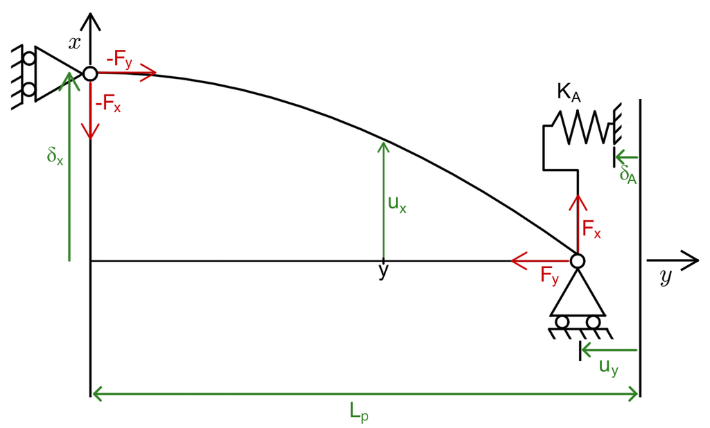

```python
Image("img(1).PNG")
```

## Paramétrage

- $L_p$: demis longueur de la poutre au repos [m]
- $F_x$: charge appliquée selon $\vec x$ [N]
- $F_y$: charge appliquée selon $\vec y$ [N]
- $E$: module de Young [$N/m^2$]
- $S$: section [$m^2$]
- $I_z$: moment quadratique de la section [$m^4$]
- $\Delta_{x}$ est le déplacement selon $\vec X$ de la section en $x=0$.
- $y$: position sur la poutre dans la configuration non déformée [m].

## Notations

- $u_x$ déplacement selon $\vec x$ de la section.
- $u_y$ déplacement selon $\vec y$ de la section.

## Modélisation

### Hypothèses

1. Les déplacements sont faibles devant $L_p$ ce qui implique que $u_x \ll L_p$ et $u_x \ll L_p$.
2. La pente $\frac{du_x}{dy}$ est faible devant $1$ ce qui implique que $\frac{du_x}{dy} \ll 1$.

### Moment fléchissant

On écrit le moment fléchissant comme suit:

$$ M_{fz} = - F_y (u_x(y)-\frac{\delta_x}{2}) + F_x (\frac{L_p}{2}-y) $$

### Courbure

La courbure est donnée par:

$$ \gamma = \frac{\frac{d^2 u_x}{dy^2}}{\left(1 + \left(\frac{d u_x}{dy}\right)^2 \right)^\frac{3}{2}} $$

Les pentes sont sont supposées faibles, la courbure $\gamma$ peut donc être approximé par :

$$ \gamma = \frac{d^2 u_x}{dy^2} $$

De plus, on peut écrire que:

\begin{align*} \gamma &= \frac{M_{fz}}{E I_z} \\ \gamma &= \frac{-F_y\frac{u_x(y)}{2} + F_x (\frac{L_p}{2}-y)}{E I_z} \end{align*}

Ce qui implique l'équation différentielle suivante:

$$ \boxed{\frac{d^2 u_x}{d y^2} + \frac{F_y}{E I_z} (u_x(y)-\frac{\delta_x}{2}) - \frac{F_x (\frac{L_p}{2}-y)}{E I_z} = 0} $$

### Adimensionnement

On introduit les variables adimensionnelles suivantes:

- $X = \frac{x}{L_p}$
- $Y = \frac{y}{L_p}$
- $U_x = \frac{u_x}{L_p}$
- $\Delta_x = \frac{\delta_x}{L_p}$
- $U_y = \frac{u_y}{L_p}$
- $K = \sqrt{E I_z}$
- $\Phi = \frac{L_p}{2}\sqrt{\dfrac{\lvert F_y\rvert}{E I_z}} = \frac{L_p}{2K}\sqrt{\lvert F_y\rvert}$. Attention donc : $\phi > 0$.
- $\Theta = - \dfrac{F_x \frac{L_p}{2}^2}{K^2}$

Ce qui se reformule en:

\begin{align} & \frac{d^2 u_x}{d y^2} + \frac{F_y}{E I_z} (u_x-\frac{\delta_x}{2}) - \frac{F_x (\frac{L_p}{2}-y)}{E I_z} = 0\\ \Leftrightarrow & \frac{1}{L_p}\frac{d^2 U_x}{d Y^2} + \frac{L_pF_y}{K^2} (U_x(y)-\frac{\Delta_x}{2}) - \frac{F_y L_p \left(\frac{1}{2}-Y\right)}{K^2} = 0\\ \Leftrightarrow & \frac{d^2 U_x}{d Y^2} + \frac{L_p^2F_y}{K^2} (U_x(y)-\frac{\Delta_x}{2}) - \frac{F_y L_p^2 \left(\frac{1}{2}-Y\right)}{K^2} = 0\\ \Leftrightarrow & \frac{d^2 U_x}{d Y^2} + 4 \Phi^2 (U_x(y)-\frac{\Delta_x}{2}) + 2 \Theta\left(1-2Y\right) = 0\\ \end{align}

Pour utiliser $\Phi$, il faut discuter du signe de $F_y$. On distinguera donc 3 cas:

#### Cas 1: $F_y > 0$

Dans ce cas, l'APA est en compression, il comprime donc la poutre. On doit alors résoudre:

$$ \boxed{\frac{d^2 U_x}{d Y^2} + 4 \Phi^2 (U_x(y)-\frac{\Delta_x}{2}) + 2 \Theta\left(1-2Y\right) = 0} $$

#### Cas 2: $F_y < 0$

Dans ce cas, l'APA est en traction, il vient donc tirer sur la poutre. On doit alors résoudre:

$$ \boxed{\frac{d^2 U_x}{d Y^2} - 4 \Phi^2 (U_x(y)-\frac{\Delta_x}{2}) + 2 \Theta\left(1-2Y\right) = 0} $$

#### Cas 3: $F_y = 0$

Ce cas correspond à de la flexion 3 points, l'APA n'exerce aucune force sur la poutre. On doit alors résoudre:

$$ \boxed{\frac{d^2 U_x}{d Y^2} + 2 \Theta\left(1-2Y\right) = 0} $$

```python
# Déclaration des variables symboliques avec Sympy
E_poutre, Iz, S_poutre, K_poutre, Ka, Lp, Y, U_max, Xw = sp.symbols(r'E I_z S K K_A Lp Y \Delta_x \Delta_xw ', real = True, positive = True)
Fx, Theta = sp.symbols('F_x Theta', real = True)
Phi = sp.symbols('Phi', real = True, positive = True, null = False)
Ux = sp.Function('U_x')(Y)
```

### Cas 1: $F_x > 0$

On cherche à determiner l'état de la poutre et de l'APA dans la position de repos ($\Delta_y=x_w$), c'est à dire sans perturbation exterieure. Dans cet état, l'APA est comprimer ce qui fait flambé la poutre. On va notamment essayé de determiné la constante $va$ qui correspond au déplacement de l'APA pour mettre en flambement la poutre.

Dans un premier temps, on cherche à résoudre l'équation différentielle sur $u_y(x)$:

```python
# ON POSE L'EQUATION DIFFERENTIELLE
ODE_case1 = sp.Eq(Ux.diff(Y,2) + 4 * Phi**2 * (Ux-U_max/2) + 2 * Theta * (1-2*Y), 0)
ODE_case1
```

$\displaystyle 4 \Phi^{2} \left(- \frac{\Delta_{x}}{2} + U_{x}{\left(Y \right)}\right) + 2 \Theta \left(1 - 2 Y\right) + \frac{d^{2}}{d Y^{2}} U_{x}{\left(Y \right)} = 0$

```python
# Solution  de l'ODE
sol1_case1 = sp.dsolve(ODE_case1, Ux, ics= {Ux.subs(Y,0):U_max, Ux.diff(Y).subs(Y, 0):0})
sol1_case1.args[1].factor(Theta).simplify()
```

$\displaystyle \frac{\Phi^{3} \Delta_{x} \cos{\left(2 \Phi Y \right)} + \Phi^{3} \Delta_{x} + \Theta \left(2 \Phi Y + \Phi \cos{\left(2 \Phi Y \right)} - \Phi - \sin{\left(2 \Phi Y \right)}\right)}{2 \Phi^{3}}$

```python
# Mise en forme de la solution
Ux_case1 = sol1_case1.args[1].simplify().factor(Theta)
Ux_case1
```

$\displaystyle \frac{\Phi^{3} \Delta_{x} \cos{\left(2 \Phi Y \right)} + \Phi^{3} \Delta_{x} + \Theta \left(2 \Phi Y + \Phi \cos{\left(2 \Phi Y \right)} - \Phi - \sin{\left(2 \Phi Y \right)}\right)}{2 \Phi^{3}}$

Afin de réduire le nombre de variable dans l'équation, on va chercher à exprimer $\theta$ comme une fonction de $\phi$ pour pouvoir le substituer dans l'équation. Pour cela on utilise la condition aux limites : $$ U_x(1) = 0 $$

```python
# DEPLACEMENT EN y = Lp
UxL_case1 = Ux_case1.subs(Y, 1).simplify()
UxL_case1
```

$\displaystyle \frac{\Phi^{3} \Delta_{x} \cos{\left(2 \Phi \right)} + \Phi^{3} \Delta_{x} + \Theta \left(\Phi \cos{\left(2 \Phi \right)} + \Phi - \sin{\left(2 \Phi \right)}\right)}{2 \Phi^{3}}$

```python
# LE DEPLACEMENT EN x = L DOIT ETRE NUL, ON EN DEDUIT Fy COMME UNE FONCTION DE Fx
Theta_case1 = sp.solve(sp.Eq(UxL_case1, 0), Theta)[0]
Theta_case1
```

$\displaystyle - \frac{2 \Phi^{3} \Delta_{x} \cos^{2}{\left(\Phi \right)}}{\Phi \cos{\left(2 \Phi \right)} + \Phi - \sin{\left(2 \Phi \right)}}$

On remaque que $F_x$ est nul quand $\frac{L_p \sqrt{F_y}}{2 K} = \Phi = \frac{\pi}{2} \pmod{\pi}$. On en déduit donc qu'on est à $\delta_x = x_w $ en mode 1 si:

$$ \Phi = \frac{\pi}{2} $$

Cela implique l'effort de compression quand $\delta_x = x_w$: $$ F_y = \frac{\pi^2 K^2}{L_p^2} $$

```python
# ON SUBSTITUE Fy PAR SON EXPRESSION
Ux_case1 = Ux_case1.subs(Theta,Theta_case1).simplify()
Ux_case1
```

$\displaystyle \frac{\Delta_{x} \left(- 2 \Phi Y \cos{\left(2 \Phi \right)} - 2 \Phi Y + 2 \Phi \cos{\left(2 \Phi \right)} + 2 \Phi - \sin{\left(2 \Phi \right)} + \sin{\left(2 \Phi Y \right)} + \sin{\left(2 \Phi \left(Y - 1\right) \right)}\right)}{2 \left(\Phi \cos{\left(2 \Phi \right)} + \Phi - \sin{\left(2 \Phi \right)}\right)}$

```python
# LA SOLUTION VERIFIE UN DEPLACEMENT EN NUL EN y = Lp
Ux_case1.subs(Y, 1)

# ET UNE COURBURE NULLE EN y = Lp/2
Ux_case1.diff(Y, 2).subs(Y, 1/2)

Ux_case1.subs(Y, 1),Ux_case1.diff(Y, 2).subs(Y, 1/2)
```

$\displaystyle \left( 0, \ 0\right)$

On va maintenant chercher à comparer les résultats obtenues avec ceux trouver via Abaqus, on va notamment comparer la forme et la courbure de la poutre lorsque celle ci est à $\delta_x = x_w$

```python
# EXPRESSION DE LA DERIVEE DE LA DEFORMEE DE LA POUTRE
dotUx_case1 = Ux_case1.diff(Y).simplify()
dotUx_case1

# EXPRESSION DE LA COURBURE DE LA POUTRE
ddotUx_case1 =  Ux_case1.diff(Y,2).simplify()
dotUx_case1
```

$\displaystyle \frac{\Phi \Delta_{x} \left(- \cos{\left(2 \Phi \right)} + \cos{\left(2 \Phi Y \right)} + \cos{\left(2 \Phi \left(Y - 1\right) \right)} - 1\right)}{\Phi \cos{\left(2 \Phi \right)} + \Phi - \sin{\left(2 \Phi \right)}}$

```python
# POUTRE
values = {
Lp:20.,     # Quart-longueur de poutre [mm]
"ep":0.15,   # Epaisseur de poutre [mm]
"bp":20.,    # Largeure de poutre [mm]
E_poutre:210.e3,   # Module de Young [MPa]
U_max:1./20,    # Déplacement vertical [mm]
Ka:1700,
}
values[Iz] = values["bp"] * values["ep"]**3 / 12 # Moment quadratique [mm^4]
values[S_poutre] = values["bp"] * values["ep"]    # Section [mm^2]
values[K_poutre] = np.sqrt(values[E_poutre] * values[Iz])
```

```python
Uxf_case1 = sp.lambdify((Y, Phi), Ux_case1.subs(values), )
dotUxf_case1 = sp.lambdify((Y, Phi), dotUx_case1.subs(values), )
ddotUxf_case1 = sp.lambdify((Y, Phi), ddotUx_case1.subs(values), )

Thetaf_case1 = sp.lambdify((Phi), Theta_case1.subs(values))
```

```python
Fyv_case1 = 29.34 # [N], Force Fy trouvé via Abaqus
Phiv_case1 = values[Lp]/2 * np.sqrt(Fyv_case1) / values[K_poutre]

FXv_case1 = - Thetaf_case1(Phiv_case1) * values[K_poutre]**2 / (values[Lp]/2)**2  # Valeur de Fx qui tend à être nulle en xw
FXv_case1
```

$\displaystyle 0.0119573668541722$

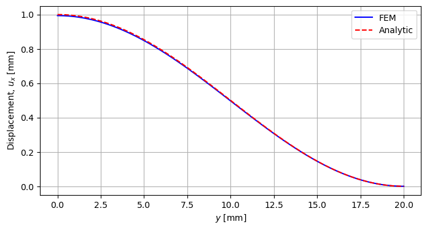

```python
plt.figure(figsize=(8,4))
plt.plot(nx_aba_case1,uy_aba_case1, '-b',label = 'FEM')
plt.plot(nx_aba_case1, Uxf_case1(nx_aba_case1/max(nx_aba_case1), Phiv_case1)*max(nx_aba_case1),'--r',label = 'Analytic')
plt.legend()
plt.xlabel("$y$ [mm]")
plt.ylabel("Displacement, $u_x$ [mm]")
plt.grid()
plt.show()
```

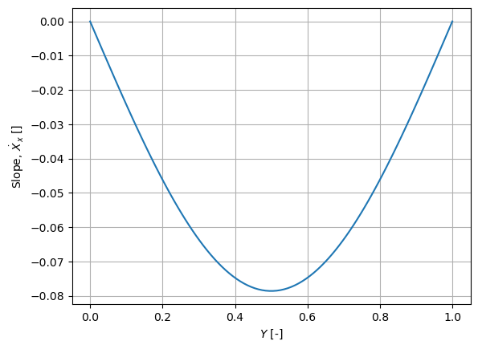

```python
plt.figure()
plt.plot(nx_aba_case1/max(nx_aba_case1), dotUxf_case1(nx_aba_case1/max(nx_aba_case1), Phiv_case1))
plt.xlabel("$Y$ [-]")
plt.ylabel(r"Slope, $\dot X_x$ []")
plt.grid()
plt.show()
```

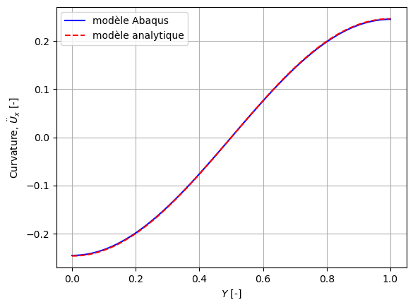

```python
plt.figure()
plt.plot(nx_aba_case1/max(nx_aba_case1), dduy_aba_case1*max(nx_aba_case1),'-b',label = 'modèle Abaqus')
plt.plot(nx_aba_case1/max(nx_aba_case1), ddotUxf_case1(nx_aba_case1/max(nx_aba_case1), Phiv_case1),'--r',label = 'modèle analytique')
plt.legend()
plt.xlabel("$Y$ [-]")
plt.ylabel(r"Curvature, $\ddot U_x$ [-]")
plt.grid()
plt.show()
```

### Déplacement selon $y$

Dans un premier temps, on cherche à calculer la longueur $u_x$ qui correspond au déplacement selon $x$ d'une section. Pour cela on fait l'hypothèse que la poutre conserve sa longueure initiale pour des petites déformations. on arrive donc au résultat suivant : $$ Y = \int_0^{Y-U_y} \sqrt{1+(\frac{\mathrm{d}U_x}{\mathrm{d}Y})^2} \mathrm{d}Y $$ Si on considère que $\frac{\mathrm{d}U_x}{\mathrm{d}Y}$ est faible devant 1, on peut écrire : $$ U_y = Y - \int_0^Y \sqrt{1+(\frac{\mathrm{d}U_x}{\mathrm{d}Y})^2} \mathrm{d}Y $$ Et avec le développement de limité de racine carrée autour 1 : $$ U_y = Y - \int_0^Y 1 + \frac{(\frac{\mathrm{d}U_x}{\mathrm{d}Y})^2}{2} \mathrm{d}Y $$

```python
# Merci CHATGPT, Sympy et WolframAlpha n'y arrive pas
# Denominator
D = Phi * sp.cos(2 * Phi) + Phi - sp.sin(2 * Phi)
A = (Phi * U_max / D)

# Expressions
term1 = (4 * sp.cos(Phi)**2) * (Y / 2 + (1 / (8 * Phi)) * (sp.sin(4 * Phi * Y - 2 * Phi) + sp.sin(2 * Phi)))
term2 = 4 * sp.cos(Phi) * (-sp.cos(2 * Phi) - 1) * (1 / (2 * Phi)) * (sp.sin(2 * Phi * Y - Phi) + sp.sin(Phi))
term3 = ((-sp.cos(2 * Phi) - 1)**2) * Y

result = Y + (A**2 / 2) * (term1 + term3 + term2)

# n,d = sp.fraction(dotUx_case1)
# result_ = (d**2 + n**2 /2).integrate((Y,0,Y))/d**2

Uy_case1 = Y*(1 - Phi**2*Iz/((Lp/2)**2*S_poutre)) - result
```

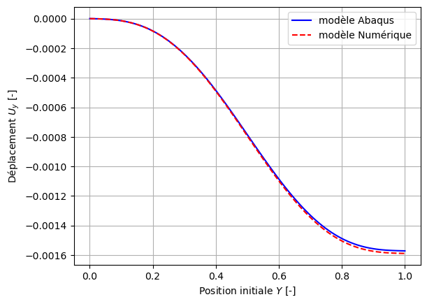

```python
# COMPARAISON Uy AVEC LE MODELE ABAQUS
Uyf_case1 = sp.lambdify((Y,Phi), Uy_case1.subs(values))

fig = plt.figure()
plt.plot(nx_aba_case1/max(nx_aba_case1), ux_aba_case1/max(nx_aba_case1),'-b',label = 'modèle Abaqus')
plt.plot(nx_aba_case1/max(nx_aba_case1),Uyf_case1(nx_aba_case1/max(nx_aba_case1),np.pi/2),'--r',label = 'modèle Numérique')
plt.legend()
plt.xlabel("Position initiale $Y$ [-]")
plt.ylabel(r"Déplacement $U_y$ [-]")
plt.grid()
plt.show()
```

```python
# CALCULE DE UY EN BOUT DE POUTRE
Dy_case1 = Uy_case1.subs(Y, 1)
Dy_case1 = Dy_case1.simplify()
Dy_case1
```

$\displaystyle - \frac{\Phi \left(4 I_{z} \Phi \left(\Phi \cos{\left(2 \Phi \right)} + \Phi - \sin{\left(2 \Phi \right)}\right)^{2} + Lp^{2} S \Delta_{x}^{2} \left(2 \Phi \cos^{2}{\left(\Phi \right)} + \Phi - 3 \sin{\left(\Phi \right)} \cos{\left(\Phi \right)}\right) \cos^{2}{\left(\Phi \right)}\right)}{Lp^{2} S \left(\Phi \cos{\left(2 \Phi \right)} + \Phi - \sin{\left(2 \Phi \right)}\right)^{2}}$

On étudie maintenant la poutre au repos :  
Pour $\delta_x = xw$, on a $\Phi = \frac{\pi}{2}$ ce qui impique que le déplacement vu bout de la poutre suivant $Y$ est alors $\Delta_{y,xw}$:

```python
# CALCULE DE UX EN BOUT DE POUTRE EN Xw
Dyw = sp.limit(Dy_case1,Phi, sp.pi/2).subs(U_max, Xw)
Dyw.simplify()
```

$\displaystyle - \frac{\pi^{2} I_{z}}{Lp^{2} S} - \frac{\pi^{2} \Delta_{xw}^{2}}{16}$

```python
# CALCULE DE LA FORCE POUR FAIRE FLAMBER LA POUTRE
Fyw = sp.pi**2 * K_poutre**2 / (Lp**2)
Fyw.subs(values).subs(sp.pi,np.pi)
```

$\displaystyle 29.146175496967$

## Déplacement de l'APA

On étudit l'état de l'APA au repos, cela permet notamment de déterminer son déplacement initial $v_a$. La poutre à besoins pour flamber d'une force $F_{xw}$ *constante* (Force critique d'Euler), cette force est la force que doit exercer l'APA sur la poutre, et par réaction la force qui le comprime. Il faut ensuite compenser le déplacement dû au flambement $\Delta_{xw}$ en bout de poutre pour que l'APA exerce toujours $F_{xw}$. On a donc la relation géométrique suivante : $$ \Delta_a = - \frac{F_{xw}}{Lp.2K_a} + \Delta_{xw} $$

```python
# CALCULE DE DA
Da = - Fyw / (Lp*2*Ka) + Dyw
Da = Da.simplify()
print('Modèle analytique : Delta_a =', Da.subs(values).subs(Xw,values[U_max]).subs(sp.pi,np.pi)*1000, 'um')
print('Modèle Abaqus : Delta_a =',-40./max(nx_aba_case1), 'um')
```

```
Modèle analytique : Delta_a = -2.01700968619689 um
Modèle Abaqus : Delta_a = -2.0 um
```

```python
# ON PEUT DONC CALCULER FY, VIA LA COMPRESSION DE L'APA:
Fy2_case1 = (2 * Ka * Lp * (Dy_case1 - Da)).simplify()
Fy2_case1
```

$\displaystyle - \frac{8 I_{z} K_{A} \Phi^{2}}{Lp S} + \frac{2 \pi^{2} I_{z} K_{A}}{Lp S} + \frac{\pi^{2} K^{2}}{Lp^{2}} - \frac{4 K_{A} Lp \Phi^{2} \Delta_{x}^{2} \cos^{4}{\left(\Phi \right)}}{\left(\Phi \cos{\left(2 \Phi \right)} + \Phi - \sin{\left(2 \Phi \right)}\right)^{2}} - \frac{2 K_{A} Lp \Phi^{2} \Delta_{x}^{2} \cos^{2}{\left(\Phi \right)}}{\left(\Phi \cos{\left(2 \Phi \right)} + \Phi - \sin{\left(2 \Phi \right)}\right)^{2}} + \frac{3 K_{A} Lp \Phi \Delta_{x}^{2} \sin{\left(2 \Phi \right)} \cos^{2}{\left(\Phi \right)}}{\left(\Phi \cos{\left(2 \Phi \right)} + \Phi - \sin{\left(2 \Phi \right)}\right)^{2}} + \frac{\pi^{2} K_{A} Lp \Delta_{xw}^{2}}{8}$

```python
Fy2f_case1 = sp.lambdify((Phi,Xw), Fy2_case1.subs(values))
```

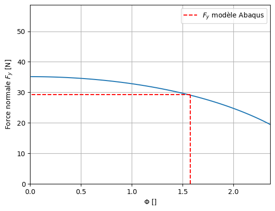

```
Force normale Abaqus Fy = 29.34 N
Force normale Analytique Fy = 29.146175496967047 N
```

```python
from scipy.optimize import brentq

Phi_ = np.linspace(0.01,1.5*Phiv_case1,100)

def Fy2f0_case1(Phi_):
    return Fy2f_case1(Phi_, values[U_max]) - (2 * Phi_* values[K_poutre]/values[Lp])**2

sol_Phi_case1 = brentq(Fy2f0_case1,a=0.01,b=1.5*Phiv_case1)
sol_Fy2_case1 = Fy2f_case1(sol_Phi_case1, values[U_max])

fig = plt.figure()
plt.plot(Phi_, Fy2f_case1(Phi_, values[U_max]))
plt.plot([-1,Phiv_case1],[Fyv_case1,Fyv_case1],'--r', label = "$F_y$ modèle Abaqus")
plt.plot([Phiv_case1,Phiv_case1],[0,Fyv_case1],'--r')
plt.xlim((0,1.5*Phiv_case1))
plt.ylim((0,2*Fyv_case1))
plt.xlabel(r'$\Phi$ []')
plt.ylabel('Force normale $F_y$ [N]')
plt.legend()
plt.grid()
plt.show()

print('Force normale Abaqus Fy =', Fyv_case1, 'N')
print('Force normale Analytique Fy =', sol_Fy2_case1, 'N')
```

# Col

On regarde ensuite ce qui se passe dans le cas critique ou la poutre et l'APA son les plus comprimés, à savoir $\delta_x = 0$

```python
fy_col = sp.symbols('F_col', real = True, positive = True)

Fy_col = Fyw + 2 * Ka * Lp * ( -Dyw - fy_col/(E_poutre*S_poutre))

sol_Fy_col = (sp.solve(sp.Eq(Fy_col.simplify(),fy_col),fy_col)[0])
sol_phi_col = Lp/2 / K_poutre * sp.sqrt(sol_Fy_col)

sol_Fy_col
```

$\displaystyle \frac{\pi^{2} E \left(16 I_{z} K_{A} Lp + 8 K^{2} S + K_{A} Lp^{3} S \Delta_{xw}^{2}\right)}{8 Lp^{2} \left(E S + 2 K_{A} Lp\right)}$

### Cas 2: $F_x < 0$

Pour ce deuxième cas, l'APA est consideré en traction. Cepndant, on applique la même méthodologie que pour le cas 1.

Pour des raisons pratiques, on garde le symbole $F_x$ positif mais on change les formules:

Dans ce cas, le moment fléchissant:

$$ M_{fz} = - F_y (u_x(y)-\frac{\delta_x}{2}) + F_x (\frac{L_p}{2}-y) $$

Ce qui implique l'équation différentielle suivante:

$$ \boxed{\frac{d^2 U_x}{d Y^2} - 4 \Phi^2 (U_x(y)-\frac{\Delta_x}{2}) + 2 \Theta\left(1-2Y\right) = 0} $$

On résout cette ODE avec Sympy:

```python
# ON POSE L'EQUATION DIFFERENTIELLE
ODE_case2 = sp.Eq(Ux.diff(Y,2) - 4 * Phi**2 * (Ux-U_max/2) + 2 * Theta * (1-2*Y), 0)
ODE_case2
```

$\displaystyle - 4 \Phi^{2} \left(- \frac{\Delta_{x}}{2} + U_{x}{\left(Y \right)}\right) + 2 \Theta \left(1 - 2 Y\right) + \frac{d^{2}}{d Y^{2}} U_{x}{\left(Y \right)} = 0$

```python
# Solution  de l'ODE
sol1_case2 = sp.dsolve(ODE_case2, Ux, ics= {Ux.subs(Y,0):U_max, Ux.diff(Y).subs(Y, 0):0})
sol1_case2
```

$\displaystyle U_{x}{\left(Y \right)} = \frac{\Delta_{x}}{2} - \frac{\Theta Y}{\Phi^{2}} + \frac{\Theta}{2 \Phi^{2}} + \frac{\left(\Phi^{3} \Delta_{x} - \Phi \Theta - \Theta\right) e^{- 2 \Phi Y}}{4 \Phi^{3}} + \frac{\left(\Phi^{3} \Delta_{x} - \Phi \Theta + \Theta\right) e^{2 \Phi Y}}{4 \Phi^{3}}$

```python
# Mise en forme de la solution
Ux_case2 = sol1_case2.args[1].simplify().factor(Theta)
Ux_case2
```

$\displaystyle \frac{\left(\Phi^{3} \Delta_{x} e^{4 \Phi Y} + 2 \Phi^{3} \Delta_{x} e^{2 \Phi Y} + \Phi^{3} \Delta_{x} + \Theta \left(- 4 \Phi Y e^{2 \Phi Y} - \Phi e^{4 \Phi Y} + 2 \Phi e^{2 \Phi Y} - \Phi + e^{4 \Phi Y} - 1\right)\right) e^{- 2 \Phi Y}}{4 \Phi^{3}}$

Afin de réduire le nombre de variable dans l'équation, on va chercher à exprimer $\Theta$ comme une fonction de $\Phi$ pour pouvoir le substituer dans l'équation. Pour cela on utilise la condition aux limites : $$ U_x(1) = 0 $$

```python
# DEPLACEMENT EN y = Lp
UxL_case2 = Ux_case2.subs(Y, 1).simplify()
UxL_case2
```

$\displaystyle \frac{\left(\Phi^{3} \Delta_{x} e^{4 \Phi} + 2 \Phi^{3} \Delta_{x} e^{2 \Phi} + \Phi^{3} \Delta_{x} - \Theta \left(\Phi e^{4 \Phi} + 2 \Phi e^{2 \Phi} + \Phi - e^{4 \Phi} + 1\right)\right) e^{- 2 \Phi}}{4 \Phi^{3}}$

```python
# LE DEPLACEMENT EN x = L DOIT ETRE NUL, ON EN DEDUIT Fy COMME UNE FONCTION DE Fx
Theta_case2 = sp.solve(sp.Eq(UxL_case2, 0), Theta)[0]
Theta_case2
```

$\displaystyle \frac{\Phi^{3} \Delta_{x} \left(e^{2 \Phi} + 1\right)}{\Phi e^{2 \Phi} + \Phi - e^{2 \Phi} + 1}$

Cela implique l'effort de compression quand $\delta_x = x_w$: $$ F_y = \frac{\pi^2 K^2}{L_p^2} $$

```python
# ON SUBSTITUE Fy PAR SON EXPRESSION
Ux_case2 = Ux_case2.subs(Theta,Theta_case2).simplify()
Ux_case2
```

$\displaystyle \frac{\Delta_{x} \left(- \left(e^{2 \Phi} + 1\right) \left(4 \Phi Y e^{2 \Phi Y} + \Phi e^{4 \Phi Y} - 2 \Phi e^{2 \Phi Y} + \Phi - e^{4 \Phi Y} + 1\right) + \left(e^{4 \Phi Y} + 2 e^{2 \Phi Y} + 1\right) \left(\Phi e^{2 \Phi} + \Phi - e^{2 \Phi} + 1\right)\right) e^{- 2 \Phi Y}}{4 \left(\Phi e^{2 \Phi} + \Phi - e^{2 \Phi} + 1\right)}$

```python
# LA SOLUTION VERIFIE UN DEPLACEMENT EN NUL EN y = Lp
Ux_case2.subs(Y, 1)

# ET UNE COURBURE NULLE EN y = Lp/2
Ux_case2.diff(Y, 2).subs(Y, 1/2)

Ux_case2.subs(Y, 1).simplify(),Ux_case2.diff(Y, 2).subs(Y, 1/2).simplify()
```

$\displaystyle \left( 0, \ \frac{2 \Phi^{2} \Delta_{x} \left(- e^{2 \Phi} + e^{2.0 \Phi}\right)}{\Phi e^{1.0 \Phi} + \Phi e^{3.0 \Phi} + e^{1.0 \Phi} - e^{3.0 \Phi}}\right)$

On va maintenant chercher à comparer les résultats obtenues avec ceux trouver via Abaqus, on va notamment comparer la forme et la courbure de la poutre.

```python
# EXPRESSION DE LA DERIVEE DE LA DEFORMEE DE LA POUTRE
dotUx_case2 = Ux_case2.diff(Y).simplify()
dotUx_case2

# EXPRESSION DE LA COURBURE DE LA POUTRE
ddotUx_case2 =  Ux_case2.diff(Y,2).simplify()
dotUx_case2
```

$\displaystyle \frac{\Phi \Delta_{x} \left(e^{2 \Phi} + e^{4 \Phi Y} - e^{2 \Phi Y} - e^{2 \Phi \left(Y + 1\right)}\right) e^{- 2 \Phi Y}}{\Phi e^{2 \Phi} + \Phi - e^{2 \Phi} + 1}$

```python
# POUTRE
values = {
Lp:20.,     # Quart-longueur de poutre [mm]
"ep":0.15,   # Epaisseur de poutre [mm]
"bp":20.,    # Largeure de poutre [mm]
E_poutre:210.e3,   # Module de Young [MPa]
Xw:1./20,   # Flambement intitial [mm]
U_max:1.62/20,    # Déplacement vertical [mm]
Ka:1700,
}
values[Iz] = values["bp"] * values["ep"]**3 / 12 # Moment quadratique [mm^4]
values[S_poutre] = values["bp"] * values["ep"]    # Section [mm^2]
values[K_poutre] = np.sqrt(values[E_poutre] * values[Iz])
```

```python
Uxf_case2 = sp.lambdify((Y, Phi), Ux_case2.subs(values), )
dotUxf_case2 = sp.lambdify((Y, Phi), dotUx_case2.subs(values), )
ddotUxf_case2 = sp.lambdify((Y, Phi), ddotUx_case2.subs(values), )

Thetaf_case2 = sp.lambdify((Phi), Theta_case2.subs(values))
```

```python
Fyv_case2 =  107.11 # [N] Force Fy trouvé via Abaqus
Phiv_case2 = values[Lp]/2 * np.sqrt(Fyv_case2) / values[K_poutre]

FXv_case2 = Thetaf_case2(Phiv_case2) * values[K_poutre]**2 / (values[Lp]/2)**2  # Valeur de FX
FXv_case2
```

$\displaystyle 12.9584843496084$

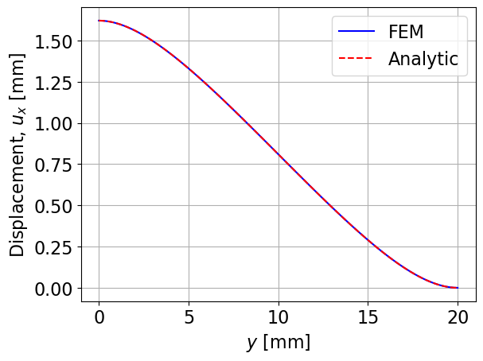

```python
import matplotlib
matplotlib.rcParams.update({'font.size': 16})
plt.figure()
plt.plot(nx_aba_case2,uy_aba_case2, '-b',label = 'FEM')
plt.plot(nx_aba_case2, Uxf_case2(nx_aba_case2/max(nx_aba_case2), Phiv_case2)*max(nx_aba_case2),'--r',label = 'Analytic')
plt.legend()
plt.xlabel("$y$ [mm]")
plt.ylabel("Displacement, $u_x$ [mm]")
plt.grid()
plt.show()
```

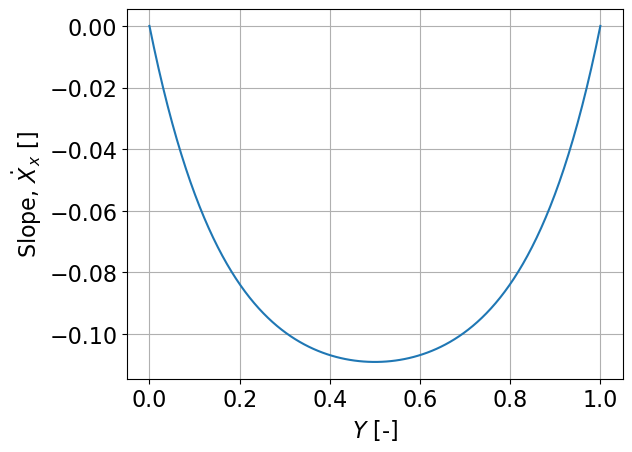

```python
plt.figure()
plt.plot(nx_aba_case2/max(nx_aba_case2), dotUxf_case2(nx_aba_case2/max(nx_aba_case2), Phiv_case2))
plt.xlabel("$Y$ [-]")
plt.ylabel(r"Slope, $\dot X_x$ []")
plt.grid()
plt.show()
```

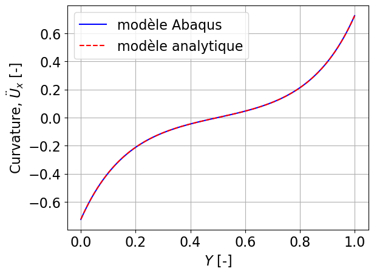

```python
plt.figure()
plt.plot(nx_aba_case2/max(nx_aba_case2), dduy_aba_case2*max(nx_aba_case2),'-b',label = 'modèle Abaqus')
plt.plot(nx_aba_case2/max(nx_aba_case2), ddotUxf_case2(nx_aba_case2/max(nx_aba_case2), Phiv_case2),'--r',label = 'modèle analytique')
plt.legend()
plt.xlabel("$Y$ [-]")
plt.ylabel(r"Curvature, $\ddot U_x$ [-]")
plt.grid()
plt.show()
```

### Déplacement selon $y$

Dans un premier temps, on cherche à calculer la longueur $u_x$ qui correspond au déplacement selon $x$ d'une section. Pour cela on fait l'hypothèse que la poutre conserve sa longueure initiale pour des petites déformations. on arrive donc au résultat suivant : $$ Y = \int_0^{Y-U_y} \sqrt{1+(\frac{\mathrm{d}U_x}{\mathrm{d}Y})^2} \mathrm{d}Y $$ Si on considère que $\frac{\mathrm{d}U_x}{\mathrm{d}Y}$ est faible devant 1, on peut écrire : $$ U_y = Y - \int_0^Y \sqrt{(1+(\frac{\mathrm{d}U_x}{\mathrm{d}Y})^2}) \mathrm{d}Y $$ Et avec le développement de limité de racine carrée autour 1 : $$ U_y = Y - \int_0^Y(1 + \frac{(\frac{\mathrm{d}U_x}{\mathrm{d}Y})^2}{2}) \mathrm{d}Y $$

```python
# Constantes
D = Phi * sp.exp(2 * Phi) + Phi - sp.exp(2 * Phi) + 1
A = (Phi**2 * U_max**2) / (2 * D**2)

# Calcul des termes
term1 = (1 / (4 * Phi)) * (sp.exp(4 * Phi * Y) - 1)
term2 = (1 / (Phi)) * (1 + sp.exp(2 * Phi)) * (sp.exp(2 * Phi * Y) - 1)
term3 = ((1 + sp.exp(2 * Phi))**2 + 2 * sp.exp(2 * Phi)) * Y
term4 = (1 / (Phi)) * (1 + sp.exp(2 * Phi)) * sp.exp(2 * Phi) * (1 - sp.exp(-2 * Phi * Y))
term5 = (sp.exp(2 * Phi)**2 / (4 * Phi)) * (1 - sp.exp(-4 * Phi * Y))

# Résultat final
result = Y + A * (term1 - term2 + term3 - term4 + term5)


n,d = sp.fraction(dotUx_case2)
result_ = (d.args[0]**2 + (n/d.args[1])**2 /2).integrate((Y,0,Y))/(d.args[0]**2)

Uy_case2 = Y - result_
```

On compare ensuite les résultats avec abaqus, on prend un déplacemment $\Delta_x = 1.62mm$

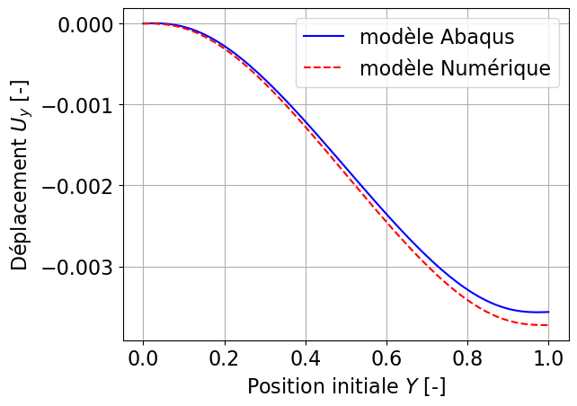

```python
# COMPARAISON Uy AVEC LE MODELE ABAQUS
Uyf_case2 = sp.lambdify((Y,Phi), Uy_case2.subs(values))

fig = plt.figure()
plt.plot(nx_aba_case2/max(nx_aba_case2), ux_aba_case2/max(nx_aba_case2),'-b',label = 'modèle Abaqus')
plt.plot(nx_aba_case2/max(nx_aba_case2),Uyf_case2(nx_aba_case2/max(nx_aba_case2),Phiv_case2),'--r',label = 'modèle Numérique')
plt.legend()
plt.xlabel("Position initiale $Y$ [-]")
plt.ylabel(r"Déplacement $U_y$ [-]")
plt.grid()
plt.show()
```

Au vu de l'erreure, une hypothèse du calcule doit être fausse. La force qui est exercé par l'APA sur la poutre est de l'ordre $F_x \approx 100$ N. Sur un poutre de section faible, cela ne peut être negligé, on introduit donc dans l'expression de $u_x$ l'élongation de la poutre.
On a la relation : $$ \frac{F_x}{S E} = e $$ d'où : $$ \frac{\phi^2 I_z}{L^2 S} = e $$

```python
Uy_case2 = Y*(1 + Phi**2*Iz/((Lp/2)**2*S_poutre)) - result
Uy_case2 = Uy_case2.simplify()
Uy_case2
```

$\displaystyle \frac{\left(- \frac{Lp^{2} \Phi S \Delta_{x}^{2} \left(4 \Phi Y \left(\left(e^{2 \Phi} + 1\right)^{2} + 2 e^{2 \Phi}\right) e^{6 \Phi Y} + 4 \left(1 - e^{2 \Phi Y}\right) \left(e^{2 \Phi} + 1\right) e^{2 \Phi \left(2 Y + 1\right)} - \left(1 - e^{4 \Phi Y}\right) e^{2 \Phi \left(Y + 2\right)} + \left(4 \left(1 - e^{2 \Phi Y}\right) \left(e^{2 \Phi} + 1\right) + e^{4 \Phi Y} - 1\right) e^{6 \Phi Y}\right)}{8} - Lp^{2} S Y \left(\Phi e^{2 \Phi} + \Phi - e^{2 \Phi} + 1\right)^{2} e^{6 \Phi Y} + Y \left(4 I_{z} \Phi^{2} + Lp^{2} S\right) \left(\Phi e^{2 \Phi} + \Phi - e^{2 \Phi} + 1\right)^{2} e^{6 \Phi Y}\right) e^{- 6 \Phi Y}}{Lp^{2} S \left(\Phi e^{2 \Phi} + \Phi - e^{2 \Phi} + 1\right)^{2}}$

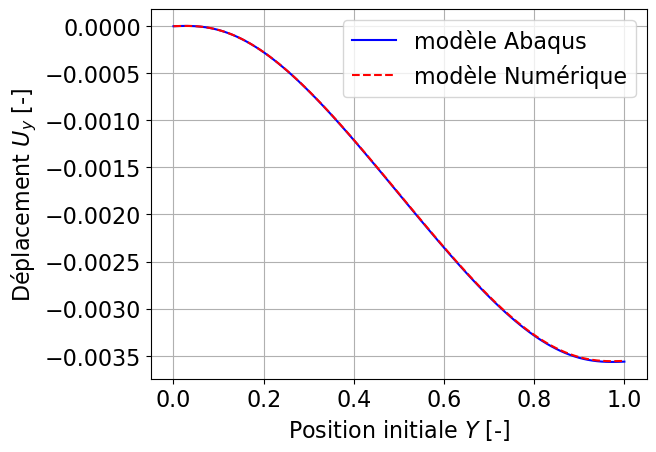

```python
# COMPARAISON Uy AVEC LE MODELE ABAQUS
Uyf_case2 = sp.lambdify((Y,Phi), Uy_case2.subs(values))

fig = plt.figure()
plt.plot(nx_aba_case2/max(nx_aba_case2), ux_aba_case2/max(nx_aba_case2),'-b',label = 'modèle Abaqus')
plt.plot(nx_aba_case2/max(nx_aba_case2),Uyf_case2(nx_aba_case2/max(nx_aba_case2), Phiv_case2),'--r',label = 'modèle Numérique')
plt.legend()
plt.xlabel("Position initiale $Y$ [-]")
plt.ylabel(r"Déplacement $U_y$ [-]")
plt.grid()
plt.show()
```

On calcule maintement le déplacement en bout de poutre $u_x(L)$ pour determiner la longueur dont l'APA s'étire.

```python
Dy_case2 = Uy_case2.subs(Y, 1)
Dy_case2 = Dy_case2.simplify()
Dy_case2
```

$\displaystyle \frac{- Lp^{2} \Phi S \Delta_{x}^{2} \left(2 \Phi \left(\left(e^{2 \Phi} + 1\right)^{2} + 2 e^{2 \Phi}\right) + 4 \left(1 - e^{2 \Phi}\right) \left(e^{2 \Phi} + 1\right) + e^{4 \Phi} - 1\right) - 4 Lp^{2} S \left(\Phi e^{2 \Phi} + \Phi - e^{2 \Phi} + 1\right)^{2} + 4 \left(4 I_{z} \Phi^{2} + Lp^{2} S\right) \left(\Phi e^{2 \Phi} + \Phi - e^{2 \Phi} + 1\right)^{2}}{4 Lp^{2} S \left(\Phi e^{2 \Phi} + \Phi - e^{2 \Phi} + 1\right)^{2}}$

En utilisant le $\Delta_a$ determiné dans le *cas 1*, on peut calculer la force $F_y$ exercé par l'APA sur la poutre

```python
# On peut donc calculer Fx :
Fy2_case2 = (2*Ka* Lp *(Dy_case2 - Da)).simplify()
Lp/2 / K_poutre * sp.sqrt(Fy2_case2).simplify()
```

$\displaystyle \frac{\sqrt{2} \sqrt{16 I_{z} K_{A} Lp \left(4 \Phi^{2} + \pi^{2}\right) + 8 \pi^{2} K^{2} S + \frac{4 K_{A} Lp^{3} \Phi S \Delta_{x}^{2} \left(- 2 \Phi \left(e^{2 \Phi} + 1\right)^{2} - 4 \Phi e^{2 \Phi} + 3 e^{4 \Phi} - 3\right)}{\left(\Phi e^{2 \Phi} + \Phi - e^{2 \Phi} + 1\right)^{2}} + \pi^{2} K_{A} Lp^{3} S \Delta_{xw}^{2}}}{8 K \sqrt{S}}$

```python
Fy2f_case2 = sp.lambdify((Phi), Fy2_case2.subs(values))
```

```
Force Fy modèle Abaqus = 107.11 N
Force Fy modèle Analytique = 105.0336694300299 N
```

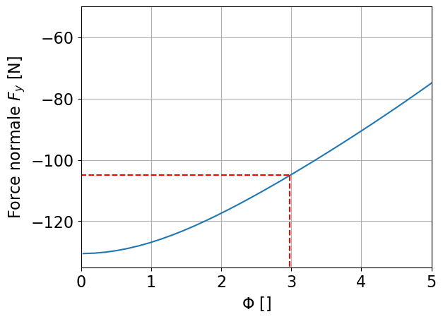

```python
Phi_ = np.linspace(0.01,5,100)*np.pi

def Fy2f0_case2(Phi_):
    return Fy2f_case2(Phi_) + (2*values[K_poutre]*Phi_/values[Lp])**2

sol_Phiv_case2  = brentq(Fy2f0_case2,a = 0.01,b = 5)

sol_Fy_case2 = Fy2f_case2(sol_Phiv_case2 )

print('Force Fy modèle Abaqus =', Fyv_case2, 'N')
print('Force Fy modèle Analytique =',  -sol_Fy_case2, 'N')

fig = plt.figure()
plt.plot(Phi_, Fy2f_case2(Phi_))
plt.plot([-1,sol_Phiv_case2 ],[sol_Fy_case2,sol_Fy_case2],'--r', label = "$F_y$ modèle Abaqus")
plt.plot([sol_Phiv_case2 ,sol_Phiv_case2 ],[-150,sol_Fy_case2],'--r')
plt.xlabel(r'$\Phi$ []')
plt.ylabel(r'Force normale $F_y$ [N]')
plt.xlim(0,5)
plt.ylim(-135,-50)
plt.grid()
plt.show()
```

```python
Fy = sp.symbols('F_y')
Fy2_case2
#Ux_case2
```

$\displaystyle \frac{8 I_{z} K_{A} \Phi^{2}}{Lp S} + \frac{2 \pi^{2} I_{z} K_{A}}{Lp S} + \frac{\pi^{2} K^{2}}{Lp^{2}} - \frac{K_{A} Lp \Phi^{2} \Delta_{x}^{2} \left(e^{2 \Phi} + 1\right)^{2}}{\left(\Phi e^{2 \Phi} + \Phi - e^{2 \Phi} + 1\right)^{2}} - \frac{2 K_{A} Lp \Phi^{2} \Delta_{x}^{2} e^{2 \Phi}}{\left(\Phi e^{2 \Phi} + \Phi - e^{2 \Phi} + 1\right)^{2}} + \frac{3 K_{A} Lp \Phi \Delta_{x}^{2} e^{4 \Phi}}{2 \left(\Phi e^{2 \Phi} + \Phi - e^{2 \Phi} + 1\right)^{2}} - \frac{3 K_{A} Lp \Phi \Delta_{x}^{2}}{2 \left(\Phi e^{2 \Phi} + \Phi - e^{2 \Phi} + 1\right)^{2}} + \frac{\pi^{2} K_{A} Lp \Delta_{xw}^{2}}{8}$

### Cas 3: $F_x = 0$

Pour ce troisième cas, l'APA ne subie aucune force. On est donc dans le cas d'une flexion 3 point. Afin de facilité l'étude de ce cas, on étudie les limites des 2 cas précédents

```python
# UX CASE 3
sp.limit(Ux_case1,Phi,0),sp.limit(Ux_case2,Phi,0)
```

$\displaystyle \left( - \frac{3 \Delta_{x} \left(- \frac{8 Y^{3}}{3} + 4 Y^{2} - \frac{4}{3}\right)}{4}, \ \frac{3 \Delta_{x} \left(\frac{16 Y^{3}}{3} - 8 Y^{2} + \frac{8}{3}\right)}{8}\right)$

```python
# UX" CASE 3
sp.limit(ddotUx_case1,Phi,0),sp.limit(ddotUx_case2,Phi,0)
```

$\displaystyle \left( 3 \Delta_{x} \left(4 Y - 2\right), \ 3 \Delta_{x} \left(4 Y - 2\right)\right)$

```python
# FY QUI DONNE LE CAS 3
sp.solve(sp.Eq(sp.limit(Fy2_case1,Phi,0),0), U_max)[0],sp.solve(sp.Eq(sp.limit(Fy2_case2,Phi,0),0), U_max)[0]
```

$\displaystyle \left( \frac{\pi \sqrt{240 I_{z} K_{A} Lp + 120 K^{2} S + 15 K_{A} Lp^{3} S \Delta_{xw}^{2}}}{12 \sqrt{K_{A}} Lp^{\frac{3}{2}} \sqrt{S}}, \ \frac{\pi \sqrt{240 I_{z} K_{A} Lp + 120 K^{2} S + 15 K_{A} Lp^{3} S \Delta_{xw}^{2}}}{12 \sqrt{K_{A}} Lp^{\frac{3}{2}} \sqrt{S}}\right)$

### Calcule de $U_{max}$

```python
Mtot, w0 = sp.symbols('M_{tot} w_0', real = True, positive = True)
a = Mtot * w0**2 / (2 * (Lp*Xw)**2)
b = Xw*Lp
c = Fx
r = sp.root((9 * a**2 * c + sp.sqrt(3) * a**2 * sp.sqrt(sp.Abs(27 * c**2 - 4 * a**2 * b**6))),3) / (sp.root(2,3) * sp.root(3,3)**2 * a) + (sp.root(sp.Rational(2, 3) ,3) * a * b**2) / sp.root(9 * a**2 * c+ sp.sqrt(3) * a**2 * sp.sqrt(sp.Abs(27 * c**2 - 4 * a**2 * b**6)),3)
U_maxv = (r/Lp).subs(Fx,(2*Phi*K_poutre/Lp)**2).subs(w0, Xw*sp.sqrt(4*Ka/Mtot)).simplify()
U_maxv
```

$\displaystyle \frac{\sqrt[3]{3} \left(\sqrt[3]{3} K_{A}^{\frac{2}{3}} Lp^{2} \Delta_{xw}^{2} + \left(9 K^{2} \Phi^{2} + \sqrt{3} \sqrt{\left|{27 K^{4} \Phi^{4} - K_{A}^{2} Lp^{6} \Delta_{xw}^{6}}\right|}\right)^{\frac{2}{3}}\right)}{3 \sqrt[3]{K_{A}} Lp \sqrt[3]{9 K^{2} \Phi^{2} + \sqrt{3} \sqrt{\left|{27 K^{4} \Phi^{4} - K_{A}^{2} Lp^{6} \Delta_{xw}^{6}}\right|}}}$